# 20212_M2_875_PEC2_Enunciado_VictorAyalaSanchez

[figure not shown]

M2.875 · Deep Learning · PEC2

2021-2 · Máster universitario en Ciencia de datos (Data science)

Estudios de Informática, Multimedia y Telecomunicación

# PEC2: Redes Neuronales Convolucionales con KERAS

A lo largo de esta práctica vamos a implementar varios modelos de redes neuronales para clasificar las imágenes de la base de datos [CIFAR10](https://www.cs.toronto.edu/~kriz/cifar.html).

La base de datos CIFAR10 está formada por imágenes en color de dimensiones 32x32 píxels que pertenecen a 10 clases:

- airplane (label 0)
- automobile (label 1)
- bird (label 2)
- cat (label 3)
- deer (label 4)
- dog (label 5)
- frog (label 6)
- horse (label 7)
- ship (label 8)
- truck (label 9)

Esta base de datos está compuesta de 60.000 registros que se dividen a su vez en 2 conjuntos: 50.000 imágenes para el conjunto de entrenamiento y 10.000 imágenes para el conjunto de test.

En el ejercicio llevaremos a cabo la tarea de construir varios modelos con el objetivo de conseguir la mayor precisión al realizar la clasificación de las imágenes. Para ello implementaremos y analizaremos los siguientes modelos:

1. Una red neuronal artificial completamente conectada
2. Una red neuronal convolucional de una capa
3. Una red neuronal convolucional profunda

 En todos los casos se utilizará la librería Keras con Tensorflow para la implementación del modelo, la compilación y el entrenamiento.

Finalmente, realizaremos una predicción de las imágenes con el mejor modelo implementado.

 **Importante: Cada uno de los ejercicios puede suponer varios minutos de ejecución, por lo que la entrega debe hacerse en formato notebook y en formato html donde se vea el código y los resultados y comentarios de cada ejercicio. Para exportar el notebook a html puede hacerse desde el menú File $\to$ Download as $\to$ HTML.**

## 1. Descarga, análisis y pre-procesado de los datos (1,5 puntos)

### 1.1 Descarga de datos

Empezamos importando algunos paquetes para la realización de la práctica y procedemos a descargar el dataset.

```python
import numpy as np
from tensorflow import keras
from keras.datasets import cifar10
from tensorflow.keras.utils import to_categorical
from keras.models import Sequential
from keras.layers import Dense, Conv2D, Flatten, Activation, Dropout, MaxPooling2D
from tensorflow.keras.optimizers import Adam, SGD, Adadelta, Adagrad
import matplotlib.pyplot as plt
import time
from sklearn.metrics import confusion_matrix, classification_report
import seaborn as sns
```

```python
# Descarga el dataset CIFAR10 y hace la partición train/test
(X_train, y_train), (X_test, y_test) = cifar10.load_data()
```

### 1.2 Análisis de los datos

**Ejercicio [0,5 pts.]:** Representar la dimensión de las variables X_train, y_train, X_test e y_test. Mostrar las imágenes de los primeros 10 registros del conjunto X_train junto con sus etiquetas en formato texto. **Nota**: Al ser las imágenes de pequeño tamaño (32x32) se recomienda escalarlas a la hora de representarlas.

```python
# Análisis del conjunto de datos descargado

print("Dimensiones del conjunto de datos: ")
print("\n")
print("Conjunto Train X")
print("Total de imágenes {}".format(X_train.shape[0]))
print("Resolución de los registros: {} x {} pixels".format(X_train.shape[1],X_train.shape[2]))
print("Registros en RGB: {}".format(X_train.shape[3]))
print("\n")
print("Conjunto Test X")
print("Total de imágenes {}".format(X_test.shape[0]))
print("Resolución de los registros: {} x {} pixels".format(X_test.shape[1],X_test.shape[2]))
print("Registros en RGB: {}".format(X_test.shape[3]))
print("\n")
print("Conjunto Train Y")
print("Total de Labels {}".format(y_train.shape[0]))
print("\n")
print("Conjunto Test Y")
print("Total de Labels {}".format(y_test.shape[0]))
```

```
Dimensiones del conjunto de datos:


Conjunto Train X
Total de imágenes 50000
Resolución de los registros: 32 x 32 pixels
Registros en RGB: 3


Conjunto Test X
Total de imágenes 10000
Resolución de los registros: 32 x 32 pixels
Registros en RGB: 3


Conjunto Train Y
Total de Labels 50000


Conjunto Test Y
Total de Labels 10000
```

```python
# Definimos un diccionario con las etiquetas
labels = {
        0:"airplane",
        1:"automobile",
        2:"bird",
        3:"cat",
        4:"deer",
        5:"dog",
        6:"frog",
        7:"horse",
        8:"ship",
        9:"truck"
}
```

Definimos una función para visualizar las imágenes del dataset

```python
def showImg(numberOfImage, datasetX, datasetY):
    plt.figure(dpi = 100)
    img = datasetX[numberOfImage]
    labelNumber = int(datasetY[numberOfImage])
    plt.title("Img: {}".format(labels[labelNumber]))
    plt.imshow(img,)
    plt.show()
```

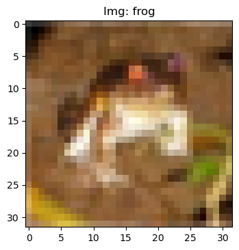

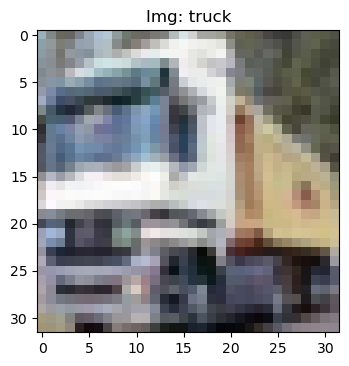

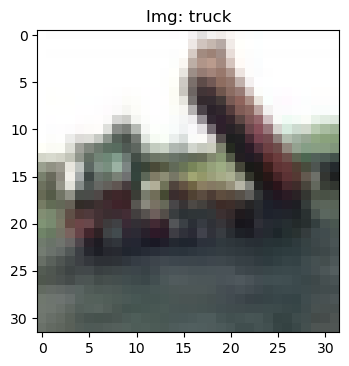

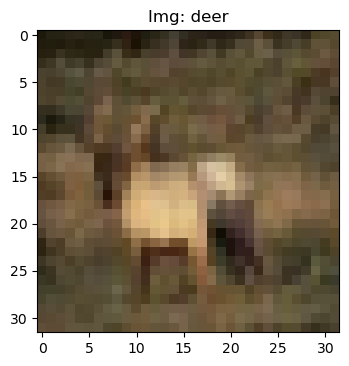

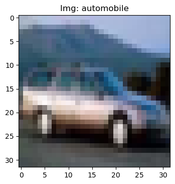

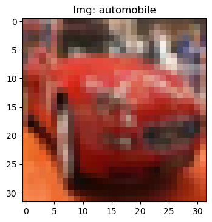

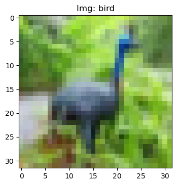

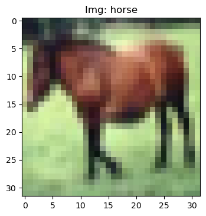

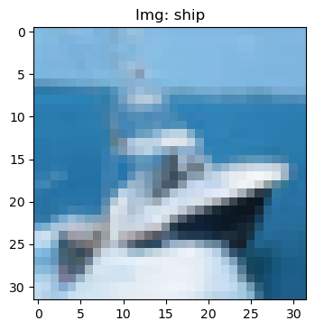

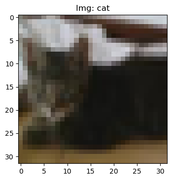

```python
for i in range(0,10):
    showImg(i, X_train, y_train)
```

### 1.3 Pre-procesado de datos

Dado que las imágenes están en color, vamos a convertirlas a escala de grises para realizar las primeras clasificaciones. Para ello utilizaremos la función `cvtColor` del paquete [OpenCV](https://pypi.org/project/opencv-python/) (cv2)

```python
import cv2

# Convierte X_train y X_test a escala de grises
X_train_grey = np.array([cv2.cvtColor(image, cv2.COLOR_BGR2GRAY) for image in X_train])
X_test_grey = np.array([cv2.cvtColor(image, cv2.COLOR_BGR2GRAY) for image in X_test])
```

**Ejercicio [0,25 pts.]:** Representar la dimensión de las variables X_train_grey y X_test_grey. Mostrar las imágenes de los primeros 10 registros del conjunto X_train_grey junto con sus etiquetas en formato texto.

```python
# TODO
X_train_grey.shape
```

```
(50000, 32, 32)
```

```python
X_test_grey.shape
```

```
(10000, 32, 32)
```

```python
print("\n")
print("Conjunto Train X grey")
print("Total de imágenes {}".format(X_train_grey.shape[0]))
print("Resolución de los registros: {} x {} pixels".format(X_train_grey.shape[1],X_train_grey.shape[2]))
print("\n")
print("Conjunto Test X grey")
print("Total de imágenes {}".format(X_test_grey.shape[0]))
print("Resolución de los registros: {} x {} pixels".format(X_test_grey.shape[1],X_test_grey.shape[2]))
```

```
Conjunto Train X grey
Total de imágenes 50000
Resolución de los registros: 32 x 32 pixels


Conjunto Test X grey
Total de imágenes 10000
Resolución de los registros: 32 x 32 pixels
```

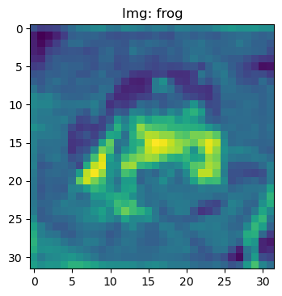

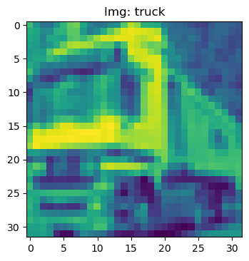

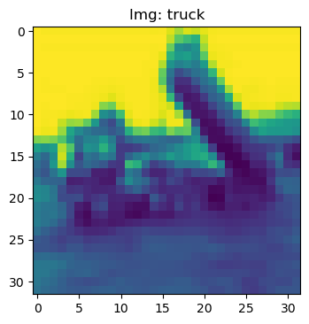

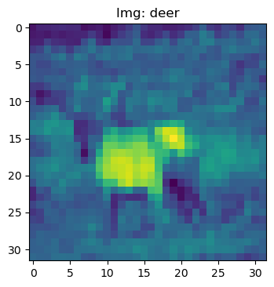

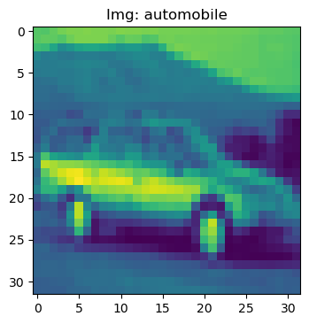

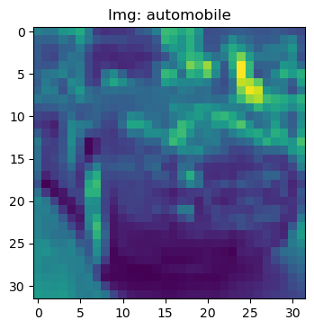

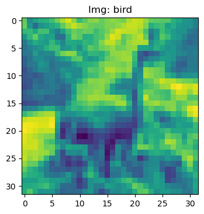

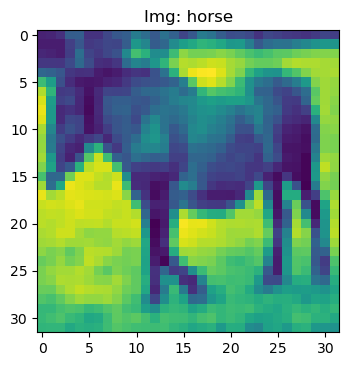

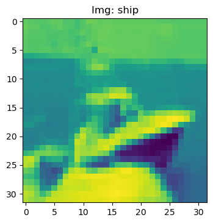

```python
for i in range(0,9):
    showImg(i, X_train_grey, y_train)
```

El primer paso para entrenar una red neuronal consiste en pre-procesar los datos de entrenamiento y test para que cuadren con el formato esperado por las entradas y salidas de la red neuronal.

Empezaremos normalizando los datos de entrada para que estén en el rango [0,1] ya que, como podemos ver a continuación, se trata de valores enteros entre 0 y 255.

```python
print("Los valores del primer registro de X_train_grey son: {}".format(X_train_grey[0]))
```

```
Los valores del primer registro de X_train_grey son: [[ 62  45  47 ... 128 121 120]
 [ 20   0   7 ...  82  77  82]
 [ 23   6  24 ...  78  78  68]
 ...
 [152 123 125 ... 117  27  32]
 [131 104 115 ... 136  58  51]
 [139 123 130 ... 174 112  90]]
```

```python
# Determinar valores mínimo y máximo
v_min = np.min(X_train_grey)
v_max = np.max(X_train_grey)
print("Los valores mínimo y máximo son {} y {}.".format(v_min, v_max))
```

```
Los valores mínimo y máximo son 0 y 255.
```

**Ejercicio [0,5 pts.]:** Normalizar los datos de entrada a la red para que estén comprendidos en el rango [0,1]. Imprimir los datos del primer registro una vez se ha llevado a cabo la normalización y comprobar de nuevo los valores máximo y mínimo.

Normalizamos los datos para que estén en el rango de 0 a 1

```python
X_train_grey_norm = (X_train_grey - v_min) / (v_max - v_min)
X_test_grey_norm = (X_test_grey - v_min) / (v_max - v_min)
```

```python
X_train_grey_norm[0]
```

```
array([[0.24313725, 0.17647059, 0.18431373, ..., 0.50196078, 0.4745098 ,
        0.47058824],
       [0.07843137, 0.        , 0.02745098, ..., 0.32156863, 0.30196078,
        0.32156863],
       [0.09019608, 0.02352941, 0.09411765, ..., 0.30588235, 0.30588235,
        0.26666667],
       ...,
       [0.59607843, 0.48235294, 0.49019608, ..., 0.45882353, 0.10588235,
        0.1254902 ],
       [0.51372549, 0.40784314, 0.45098039, ..., 0.53333333, 0.22745098,
        0.2       ],
       [0.54509804, 0.48235294, 0.50980392, ..., 0.68235294, 0.43921569,
        0.35294118]])
```

```python
X_train_grey_norm[0][0]
```

```
array([0.24313725, 0.17647059, 0.18431373, 0.20392157, 0.2745098 ,
       0.3372549 , 0.39607843, 0.41176471, 0.43921569, 0.45098039,
       0.38431373, 0.37254902, 0.43529412, 0.42352941, 0.39607843,
       0.36470588, 0.39607843, 0.39215686, 0.35294118, 0.41176471,
       0.40784314, 0.38039216, 0.38823529, 0.4       , 0.44705882,
       0.49019608, 0.51372549, 0.48627451, 0.49019608, 0.50196078,
       0.4745098 , 0.47058824])
```

**Ejercicio [0,25 pts.]:** Codificar los valores de las etiquetas de salida en un vector one-hot. Por ejemplo, el vector de salida para una imagen que contiene un 5 sería: [0., 0., 0., 0., 0., 1., 0., 0., 0., 0.]. Comprobar el resultado imprimiendo su dimensión y mostrando algún registro.

**Nota**: Se puede utilizar la función `to_categorical` de `tensorflow.keras.utils`.

```python
y_train[:3]
```

```
array([[6],
       [9],
       [9]], dtype=uint8)
```

```python
y_test[:3]
```

```
array([[3],
       [8],
       [8]], dtype=uint8)
```

Hacemos One Hot Encoder sobre el target

```python
y_train_oh = to_categorical(y_train)
y_test_oh = to_categorical(y_test)
```

```python
y_train_oh[0]
```

```
array([0., 0., 0., 0., 0., 0., 1., 0., 0., 0.], dtype=float32)
```

```python
y_test_oh[:3]
```

```
array([[0., 0., 0., 1., 0., 0., 0., 0., 0., 0.],
       [0., 0., 0., 0., 0., 0., 0., 0., 1., 0.],
       [0., 0., 0., 0., 0., 0., 0., 0., 1., 0.]], dtype=float32)
```

## 2. Red Neuronal Artificial (ANN) completamente conectada [2,5 puntos]

A continuación implementaremos una red neuronal *feed-forward fully connected* y llevaremos a cabo el entrenamiento y test sobre el dataset CIFAR.

### 2.1 Pre-procesado de datos

Dado que en una red neuronal artificial las entradas son unidimensionales, lo primero que tenemos que hacer es redimensionar los datos de entrada (las imágenes) para convertirlos en arrays de una dimensión.

**Ejercicio [0,5 pts.]:** Modificar los conjuntos X_train_grey y X_test_grey para que sus registros sean arrays unidimensionales de dimensión 32x32 = 1024 datos. Comprobad el resultado imprimiendo las dimensiones de las variables.

```python
X_train_grey_norm.shape
```

```
(50000, 32, 32)
```

```python
X_test_grey_norm.shape
```

```
(10000, 32, 32)
```

Hacemos el reshape de test y train

```python
# TODO
X_train_gflat = X_train_grey_norm.reshape(50000, 1024)
X_test_gflat = X_test_grey_norm.reshape(10000, 1024)
```

```python
print(X_train_gflat.shape)
print(X_test_gflat.shape)
```

```
(50000, 1024)
(10000, 1024)
```

```python
X_train_gflat[0]
```

```
array([0.24313725, 0.17647059, 0.18431373, ..., 0.68235294, 0.43921569,
       0.35294118])
```

### 2.2 Creación del modelo

Vamos a usar un modelo `Sequential` de Keras

**Ejercicio [2 pts.]:** Implementa el modelo de red neuronal artificial:

- Diseña la arquitectura para el modelo de clasificación con las siguientes características:
- 6 capas ocultas de 128 neuronas.
- 3 capas de Dropout del 20% (rate=0,2) intercaladas cada 2 capas densas.
- Función de activación de las capas intermedias: ReLU.
- 1 capa de salida con las dimensiones y función de activación adecuadas para realizar la clasificación.
- Imprime el modelo para ver el número de parámetros a entrenar.
- Compila el modelo con la función de pérdida más adecuada, el optimizador SGD, una velocidad de aprendizaje de 0.01, y la métrica Accuracy.
- Ajusta el modelo con 100 épocas y un tamaño del batch de 128. Mide el tiempo de entrenamiento.
- Muestra las gráficas de accuracy y loss. En cada gráfica debe visualizarse la curva de entrenamiento y la de validación. NOTA: Se recomienda hacer una función que imprima ambas gráficas para poder reutilizarla en próximos apartados.
- Realiza la evaluación del modelo para mostrar la pérdida y la precisión final.

Estamos trabajando con el GPU desde Colab

```python
from tensorflow.python.client import device_lib

device_lib.list_local_devices()
```

```
[name: "/device:CPU:0"
 device_type: "CPU"
 memory_limit: 268435456
 locality {
 }
 incarnation: 9266133088731259620
 xla_global_id: -1, name: "/device:GPU:0"
 device_type: "GPU"
 memory_limit: 14465892352
 locality {
   bus_id: 1
   links {
   }
 }
 incarnation: 14571930916723350091
 physical_device_desc: "device: 0, name: Tesla T4, pci bus id: 0000:00:04.0, compute capability: 7.5"
 xla_global_id: 416903419]
```

```python
in_dims = X_train_gflat.shape[1]
out_dims = y_train_oh.shape[1]

print(in_dims)
print(out_dims)
```

```
1024
10
```

```python
# Crear el modelo ANN
model = Sequential()
model.add(Dense(128,input_dim=in_dims, activation='relu'))
model.add(Dense(128, activation='relu'))
model.add(Dropout(0.20))
model.add(Dense(128, activation='relu'))
model.add(Dense(128, activation='relu'))
model.add(Dropout(0.20))
model.add(Dense(128, activation='relu'))
model.add(Dense(128, activation='relu'))
model.add(Dropout(0.20))
model.add(Dense(out_dims,activation='softmax'))
```

```python
model.summary()
```

```
Model: "sequential"
_________________________________________________________________
 Layer (type)                Output Shape              Param #
=================================================================
 dense (Dense)               (None, 128)               131200

 dense_1 (Dense)             (None, 128)               16512

 dropout (Dropout)           (None, 128)               0

 dense_2 (Dense)             (None, 128)               16512

 dense_3 (Dense)             (None, 128)               16512

 dropout_1 (Dropout)         (None, 128)               0

 dense_4 (Dense)             (None, 128)               16512

 dense_5 (Dense)             (None, 128)               16512

 dropout_2 (Dropout)         (None, 128)               0

 dense_6 (Dense)             (None, 10)                1290

=================================================================
Total params: 215,050
Trainable params: 215,050
Non-trainable params: 0
_________________________________________________________________
```

```python
# Compile
model.compile(loss='categorical_crossentropy', optimizer=SGD(learning_rate=0.01), metrics=['accuracy'])
```

```python
# Entrenar el modelo

import time
start_time = time.time()

history = model.fit(X_train_gflat, y_train_oh,
                    validation_data=(X_test_gflat, y_test_oh),
                    epochs=100,
                    batch_size=128,
                    verbose=0)

end_time = time.time() - start_time
```

```python
end_time
```

```
142.75508737564087
```

```python
# Plot del training loss y el accuracy
def plot_prediction(n_epochs, mfit):
    plt.plot(mfit.history['accuracy'])
    plt.plot(mfit.history['val_accuracy'])
    plt.title('Model accuracy')
    plt.ylabel('Accuracy')
    plt.xlabel('Epoch')
    plt.legend(['Train', 'Test'], loc='upper left')
    plt.show()

    plt.plot(mfit.history['loss'])
    plt.plot(mfit.history['val_loss'])
    plt.title('Model loss')
    plt.ylabel('Loss')
    plt.xlabel('Epoch')
    plt.legend(['Train_loss', 'Test_loss'], loc='upper left')
    plt.show()
```

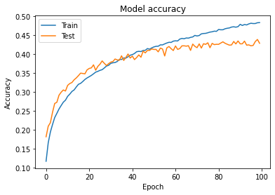

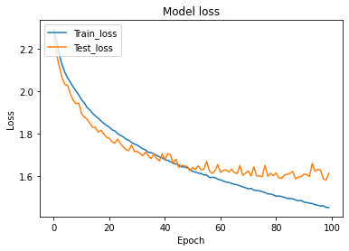

```python
plot_prediction(100, history)
```

El modelo tiene un accuracy pobre, el train ligeramente mayor al test; esto nos da cuenta de cierto nivel de overfitting

```python
# Resultados
import pandas as pd
pred_y = model.predict(X_test_gflat)

target_names = ["airplane","automobile","bird",
               "cat","deer","dog","frog","horse","ship","truck"]

cm = pd.DataFrame(
    confusion_matrix(y_test_oh.argmax(axis=1), pred_y.argmax(axis=1)),
    index= target_names,
    columns=target_names
)
cm
```

|  | airplane | automobile | bird | cat | deer | dog | frog | horse | ship | truck |
| --- | --- | --- | --- | --- | --- | --- | --- | --- | --- | --- |
| airplane | 333 | 66 | 59 | 17 | 59 | 16 | 91 | 29 | 264 | 66 |
| automobile | 9 | 637 | 0 | 15 | 13 | 12 | 59 | 8 | 79 | 168 |
| bird | 75 | 38 | 215 | 96 | 144 | 99 | 202 | 47 | 55 | 29 |
| cat | 30 | 56 | 36 | 254 | 57 | 149 | 261 | 52 | 25 | 80 |
| deer | 49 | 50 | 96 | 47 | 298 | 49 | 248 | 81 | 56 | 26 |
| dog | 17 | 35 | 45 | 216 | 56 | 330 | 160 | 61 | 32 | 48 |
| frog | 8 | 88 | 25 | 59 | 63 | 31 | 646 | 20 | 22 | 38 |
| horse | 24 | 56 | 31 | 58 | 78 | 90 | 88 | 447 | 33 | 95 |
| ship | 52 | 135 | 15 | 24 | 24 | 16 | 33 | 20 | 602 | 79 |
| truck | 9 | 248 | 7 | 33 | 9 | 14 | 58 | 30 | 70 | 522 |

```python
#Accuracy
# La métrica de Accuracy es muy pobre
from sklearn.metrics import accuracy_score
accuracy_score(y_test_oh.argmax(axis=1), pred_y.argmax(axis=1))
```

```
0.4284
```

```python
from sklearn.metrics import classification_report

print(classification_report(y_test_oh.argmax(axis=1), pred_y.argmax(axis=1), target_names=target_names))
```

```
              precision    recall  f1-score   support

    airplane       0.55      0.33      0.41      1000
  automobile       0.45      0.64      0.53      1000
        bird       0.41      0.21      0.28      1000
         cat       0.31      0.25      0.28      1000
        deer       0.37      0.30      0.33      1000
         dog       0.41      0.33      0.37      1000
        frog       0.35      0.65      0.45      1000
       horse       0.56      0.45      0.50      1000
        ship       0.49      0.60      0.54      1000
       truck       0.45      0.52      0.49      1000

    accuracy                           0.43     10000
   macro avg       0.44      0.43      0.42     10000
weighted avg       0.44      0.43      0.42     10000
```

## 3. Red Neuronal Convolucional de una capa [2.5 puntos]

A continuación implementaremos una red neuronal convolucional de una capa y realizaremos el entrenamiento y test sobre el dataset CIFAR.

Se recomienda, a partir de este punto realizar el entrenamiento en una máquina con GPU (puede activarse en plataformas como Google Colab o Kaggle) con el fin de reducir los tiempos de entrenamiento.

### 3.1 Pre-procesado de datos

El primer paso para entrenar una red neuronal consiste en pre-procesar los datos de entrenamiento y test para que cuadren con las dimensiones de la entrada de la red neuronal.

**Ejercicio [0,5 pts.]:** Ajustar el tamaño de los datos de entrenamiento y test para que tengan 4 dimensiones (la última dimensión tiene que ser 1 para indicar que las imágenes están en escala de grises).

**Nota**: Utilizar el número de datos de entrenamiento y test y el tamaño de las imágenes.

```python
import tensorflow as tf

tf.test.gpu_device_name()
```

```
'/device:GPU:0'
```

https://www.tutorialspoint.com/google_colab/google_colab_using_free_gpu.htm

Realizamos el reshape sobre las matrices

```python
## TODO

x_train_4D = X_train_grey_norm.reshape(50000,32,32,1)
x_test_4D = X_test_grey_norm.reshape(10000,32,32,1)

print(x_train_4D.shape)
print("------")
print(x_test_4D.shape)
```

```
(50000, 32, 32, 1)
------
(10000, 32, 32, 1)
```

```python
x_train_4D[0][0]
```

```
array([[0.24313725],
       [0.17647059],
       [0.18431373],
       [0.20392157],
       [0.2745098 ],
       [0.3372549 ],
       [0.39607843],
       [0.41176471],
       [0.43921569],
       [0.45098039],
       [0.38431373],
       [0.37254902],
       [0.43529412],
       [0.42352941],
       [0.39607843],
       [0.36470588],
       [0.39607843],
       [0.39215686],
       [0.35294118],
       [0.41176471],
       [0.40784314],
       [0.38039216],
       [0.38823529],
       [0.4       ],
       [0.44705882],
       [0.49019608],
       [0.51372549],
       [0.48627451],
       [0.49019608],
       [0.50196078],
       [0.4745098 ],
       [0.47058824]])
```

### 3.2 Creación del modelo

Se quiere implementar un modelo secuencial de Keras con las siguientes características:

- La primera capa que añadiremos será una capa convolucional con las siguientes propiedades:
  - Número de kernels (neuronas) de la primera capa oculta: 64 neuronas
  - Tamaño de los kernels: 3x3
  - Activación de los kernels: ReLU
- A continuación añadiremos una capa Flatten para conectar la salida de la capa convolucional con la entrada de una capa densa.
- Por último, añadiremos una capa densa de salida con el número de neuronas y función de activación adecuadas para llevar a cabo la clasificación.

**Ejercicio [1,5 pts.]:** Construir el modelo según los requerimientos indicados, además:

- Imprime el modelo para ver el número de parámetros a entrenar.
- Compila el modelo con la función de pérdida más adecuada, el optimizador ADAM y la métrica Accuracy.
- Ajusta el modelo con 20 épocas y un tamaño del batch de 128. Mide el tiempo de entrenamiento.
- Muestra las gráficas de accuracy y loss. En cada gráfica debe visualizarse la curva de entrenamiento y la de validación
- Realiza la evaluación del modelo para mostrar la pérdida y la precisión final.

```python
x_train_4D.shape[1:]
```

```
(32, 32, 1)
```

```python
# Crear la CNN monocapa

CNN_Mono = Sequential()
CNN_Mono.add(Conv2D(64, kernel_size=(3, 3), activation="relu", input_shape=(32,32,1)))
CNN_Mono.add(Flatten())
CNN_Mono.add(Dense(10, activation='softmax'))


print(CNN_Mono.summary())
```

```
Model: "sequential_1"
_________________________________________________________________
 Layer (type)                Output Shape              Param #
=================================================================
 conv2d (Conv2D)             (None, 30, 30, 64)        640

 flatten (Flatten)           (None, 57600)             0

 dense_7 (Dense)             (None, 10)                576010

=================================================================
Total params: 576,650
Trainable params: 576,650
Non-trainable params: 0
_________________________________________________________________
None
```

```python
# Compile
CNN_Mono.compile(loss='categorical_crossentropy', optimizer=Adam(learning_rate=0.01), metrics=['accuracy'])
```

```python
# Entrenamiento del modelo
import time
start_time = time.time()

history = CNN_Mono.fit(x_train_4D, y_train_oh,
                       validation_data=(x_test_4D, y_test_oh),
                       epochs=20,
                       batch_size=128,
                       verbose=0
                       )

end_time = time.time() - start_time
print(end_time)
```

```
82.51530885696411
```

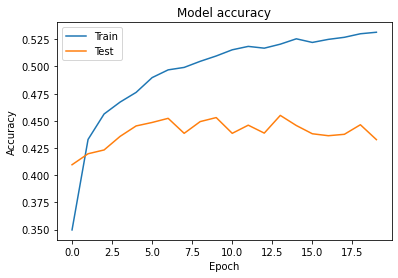

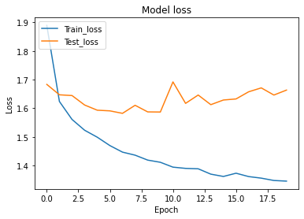

```python
plot_prediction(20, history)
```

```python
# Resultados
pred_y = CNN_Mono.predict(x_test_4D)

target_names = ["airplane","automobile","bird",
               "cat","deer","dog","frog","horse","ship","truck"]

cm = pd.DataFrame(
    confusion_matrix(y_test_oh.argmax(axis=1), pred_y.argmax(axis=1)),
    index= target_names,
    columns=target_names
)
cm
```

|  | airplane | automobile | bird | cat | deer | dog | frog | horse | ship | truck |
| --- | --- | --- | --- | --- | --- | --- | --- | --- | --- | --- |
| airplane | 460 | 20 | 103 | 27 | 81 | 15 | 12 | 62 | 151 | 69 |
| automobile | 34 | 513 | 6 | 34 | 20 | 14 | 22 | 36 | 78 | 243 |
| bird | 94 | 8 | 297 | 119 | 144 | 138 | 40 | 93 | 35 | 32 |
| cat | 37 | 21 | 126 | 278 | 101 | 225 | 27 | 124 | 16 | 45 |
| deer | 57 | 7 | 174 | 116 | 326 | 109 | 36 | 137 | 19 | 19 |
| dog | 22 | 9 | 107 | 141 | 91 | 400 | 21 | 174 | 12 | 23 |
| frog | 35 | 49 | 96 | 162 | 95 | 78 | 328 | 90 | 20 | 47 |
| horse | 29 | 9 | 50 | 101 | 61 | 111 | 6 | 575 | 16 | 42 |
| ship | 156 | 79 | 39 | 18 | 18 | 19 | 10 | 28 | 565 | 68 |
| truck | 58 | 123 | 18 | 45 | 12 | 20 | 14 | 67 | 58 | 585 |

```python
accuracy_score(y_test_oh.argmax(axis=1), pred_y.argmax(axis=1))
```

```
0.4327
```

```python
print(classification_report(y_test_oh.argmax(axis=1), pred_y.argmax(axis=1), target_names=target_names))
```

```
              precision    recall  f1-score   support

    airplane       0.47      0.46      0.46      1000
  automobile       0.61      0.51      0.56      1000
        bird       0.29      0.30      0.29      1000
         cat       0.27      0.28      0.27      1000
        deer       0.34      0.33      0.33      1000
         dog       0.35      0.40      0.38      1000
        frog       0.64      0.33      0.43      1000
       horse       0.41      0.57      0.48      1000
        ship       0.58      0.56      0.57      1000
       truck       0.50      0.58      0.54      1000

    accuracy                           0.43     10000
   macro avg       0.45      0.43      0.43     10000
weighted avg       0.45      0.43      0.43     10000
```

### 3.3 GPU vs CPU

**Ejercicio [0,5 pts.]:** Volver a entrenar el modelo desde cero en un entorno sin GPU (sólo con CPU) y compara los tiempos de entrenamiento. Comenta los resultados.

Entorno sin GPU

```python
from tensorflow.python.client import device_lib

device_lib.list_local_devices()
```

```
[name: "/device:CPU:0"
 device_type: "CPU"
 memory_limit: 268435456
 locality {
 }
 incarnation: 12780973025737440650
 xla_global_id: -1]
```

```python
CNN_Mono = Sequential()
CNN_Mono.add(Conv2D(64, kernel_size=(3, 3), activation="relu", input_shape=(32,32,1)))
CNN_Mono.add(Flatten())
CNN_Mono.add(Dense(10, activation='softmax'))


print(CNN_Mono.summary())
```

```
Model: "sequential_1"
_________________________________________________________________
 Layer (type)                Output Shape              Param #
=================================================================
 conv2d_1 (Conv2D)           (None, 30, 30, 64)        640

 flatten_1 (Flatten)         (None, 57600)             0

 dense_1 (Dense)             (None, 10)                576010

=================================================================
Total params: 576,650
Trainable params: 576,650
Non-trainable params: 0
_________________________________________________________________
None
```

```python
# Compile
CNN_Mono.compile(loss='categorical_crossentropy', optimizer=Adam(learning_rate=0.01), metrics=['accuracy'])
```

```python
import time
start_time = time.time()

history = CNN_Mono.fit(x_train_4D, y_train_oh,
                       validation_data=(x_test_4D, y_test_oh),
                       epochs=20,
                       batch_size=128,
                       verbose=0
                       )

end_time = time.time() - start_time
print(end_time)
```

```
583.2087306976318
```

```python
pred_y = CNN_Mono.predict(x_test_4D)
```

```python
#Accuracy
from sklearn.metrics import accuracy_score
accuracy_score(y_test_oh.argmax(axis=1), pred_y.argmax(axis=1))
```

```
0.2533
```

Esta vez obtenemos un accuracy más bajo

```python
# Resultados
import pandas as pd
pred_y = CNN_Mono.predict(x_test_4D)

target_names = ["airplane","automobile","bird",
               "cat","deer","dog","frog","horse","ship","truck"]

cm = pd.DataFrame(
    confusion_matrix(y_test_oh.argmax(axis=1), pred_y.argmax(axis=1)),
    index= target_names,
    columns=target_names
)
cm
```

|  | airplane | automobile | bird | cat | deer | dog | frog | horse | ship | truck |
| --- | --- | --- | --- | --- | --- | --- | --- | --- | --- | --- |
| airplane | 364 | 7 | 92 | 12 | 99 | 33 | 5 | 21 | 351 | 16 |
| automobile | 84 | 174 | 35 | 67 | 80 | 45 | 26 | 22 | 347 | 120 |
| bird | 116 | 3 | 307 | 46 | 199 | 54 | 13 | 19 | 231 | 12 |
| cat | 69 | 11 | 189 | 118 | 240 | 114 | 6 | 29 | 202 | 22 |
| deer | 94 | 7 | 194 | 39 | 361 | 67 | 7 | 35 | 191 | 5 |
| dog | 75 | 11 | 209 | 69 | 234 | 169 | 12 | 37 | 176 | 8 |
| frog | 124 | 40 | 133 | 94 | 153 | 53 | 75 | 29 | 253 | 46 |
| horse | 111 | 16 | 161 | 63 | 218 | 120 | 10 | 149 | 132 | 20 |
| ship | 144 | 10 | 69 | 12 | 68 | 30 | 6 | 10 | 637 | 14 |
| truck | 108 | 65 | 60 | 63 | 58 | 39 | 15 | 22 | 391 | 179 |

El tiempo con GPU es de 82.51 segundos contra 583.20 segundos en entorno de CPU. En este tipo de casos es preferible utilizar graphics processing unit (GPU) debido a que es un hardware diseñado especifacamente para realizar tareas de procesamiento en paralelo. Se evidencia una diferencia notable en el tiempo de entrenamiento comparando un entorno de CPU vs GPU

## 4. Deep CNN con Maxpooling y Dropout [2 puntos]

En el ejercicio anterior hemos implementado una red convolucional de una sola capa. Ahora vamos a implementar una red neuronal convolucional profunda y veremos como esto se traduce en un mejor rendimiento en los resultados.

### 4.1 Creación del modelo

En este caso volveremos a utilizar el modelo `Sequential` de Keras que constará de:

- Dos capas convolucionales de 32 kernels cada una de tamaño 3x3
- Una capa de MaxPooling con un tamaño de 2x2
- Una capa de Dropout con un rate=0.2
- Dos capas convolucionales de 64 kernels cada una de tamaño 3x3
- Una capa de MaxPooling con un tamaño de 2x2
- Una capa de Dropout con un rate=0.2
- Dos capas convolucionales de 128 kernels cada una de tamaño 3x3
- Una capa de MaxPooling con un tamaño de 2x2
- Una capa de Dropout con un rate=0.2
- Todas las capas convolucionales con función de activación ReLU y padding = same
- Una capa Flatten
- Una capa densa con 128 neuronas y función de activación ReLU
- Una capa de Dropout con un rate=0.2
- Una capa densa de salida con el número de neuronas y la función de activación necesarias para llevar a cabo la clasificación

**Ejercicio [1,5 pts.]:** Construir el modelo según los requerimientos indicados, además:

- Imprime el modelo para ver el número de parámetros a entrenar.
- Compila el modelo con la función de pérdida más adecuada, el optimizador SGD (con learning rate de 0.001 y momentum de 0.9) y la métrica Accuracy.
- Ajusta el modelo con 150 épocas y un tamaño del batch de 128. Mide el tiempo de entrenamiento.
- Muestra las gráficas de accuracy y loss. En cada gráfica debe visualizarse la curva de entrenamiento y la de validación
- Realiza la evaluación del modelo para mostrar la pérdida y la precisión final.

```python
x_train_4D[0]
```

```
array([[[0.24313725],
        [0.17647059],
        [0.18431373],
        ...,
        [0.50196078],
        [0.4745098 ],
        [0.47058824]],

       [[0.07843137],
        [0.        ],
        [0.02745098],
        ...,
        [0.32156863],
        [0.30196078],
        [0.32156863]],

       [[0.09019608],
        [0.02352941],
        [0.09411765],
        ...,
        [0.30588235],
        [0.30588235],
        [0.26666667]],

       ...,

       [[0.59607843],
        [0.48235294],
        [0.49019608],
        ...,
        [0.45882353],
        [0.10588235],
        [0.1254902 ]],

       [[0.51372549],
        [0.40784314],
        [0.45098039],
        ...,
        [0.53333333],
        [0.22745098],
        [0.2       ]],

       [[0.54509804],
        [0.48235294],
        [0.50980392],
        ...,
        [0.68235294],
        [0.43921569],
        [0.35294118]]])
```

```python
x_test_4D[0]
```

```
array([[[0.38431373],
        [0.38039216],
        [0.4       ],
        ...,
        [0.32156863],
        [0.30980392],
        [0.28627451]],

       [[0.38431373],
        [0.36862745],
        [0.38431373],
        ...,
        [0.31764706],
        [0.30196078],
        [0.29411765]],

       [[0.37647059],
        [0.35686275],
        [0.36862745],
        ...,
        [0.32941176],
        [0.31764706],
        [0.29803922]],

       ...,

       [[0.52156863],
        [0.42352941],
        [0.37647059],
        ...,
        [0.41176471],
        [0.27843137],
        [0.36078431]],

       [[0.49019608],
        [0.43137255],
        [0.36470588],
        ...,
        [0.35294118],
        [0.34901961],
        [0.28235294]],

       [[0.45882353],
        [0.44313725],
        [0.38039216],
        ...,
        [0.33333333],
        [0.36078431],
        [0.29411765]]])
```

```python
y_train_oh[0]
```

```
array([0., 0., 0., 0., 0., 0., 1., 0., 0., 0.], dtype=float32)
```

```python
y_test_oh[0]
```

```
array([0., 0., 0., 1., 0., 0., 0., 0., 0., 0.], dtype=float32)
```

```python
# Crear la CNN profunda
CNN = Sequential()
CNN.add(Conv2D(32, kernel_size=(3, 3), activation="relu", padding="same", input_shape=(32,32,1)))
CNN.add(Conv2D(32, kernel_size=(3, 3), activation='relu', padding="same"))
CNN.add(MaxPooling2D(pool_size=(2, 2)))
CNN.add(Dropout(0.20))
CNN.add(Conv2D(64, kernel_size=(3, 3), activation="relu", padding="same"))
CNN.add(Conv2D(64, kernel_size=(3, 3), activation='relu', padding="same"))
CNN.add(MaxPooling2D(pool_size=(2, 2)))
CNN.add(Dropout(0.20))
CNN.add(Conv2D(128, kernel_size=(3, 3), activation="relu", padding="same"))
CNN.add(Conv2D(128, kernel_size=(3, 3), activation='relu', padding="same"))
CNN.add(MaxPooling2D(pool_size=(2, 2)))
CNN.add(Dropout(0.20))
CNN.add(Flatten())
CNN.add(Dense(128, activation='relu'))
CNN.add(Dropout(0.20))
CNN.add(Dense(out_dims,activation='softmax'))

print(CNN.summary())
```

```
Model: "sequential_2"
_________________________________________________________________
 Layer (type)                Output Shape              Param #
=================================================================
 conv2d_1 (Conv2D)           (None, 32, 32, 32)        320

 conv2d_2 (Conv2D)           (None, 32, 32, 32)        9248

 max_pooling2d (MaxPooling2D  (None, 16, 16, 32)       0
 )

 dropout_3 (Dropout)         (None, 16, 16, 32)        0

 conv2d_3 (Conv2D)           (None, 16, 16, 64)        18496

 conv2d_4 (Conv2D)           (None, 16, 16, 64)        36928

 max_pooling2d_1 (MaxPooling  (None, 8, 8, 64)         0
 2D)

 dropout_4 (Dropout)         (None, 8, 8, 64)          0

 conv2d_5 (Conv2D)           (None, 8, 8, 128)         73856

 conv2d_6 (Conv2D)           (None, 8, 8, 128)         147584

 max_pooling2d_2 (MaxPooling  (None, 4, 4, 128)        0
 2D)

 dropout_5 (Dropout)         (None, 4, 4, 128)         0

 flatten_1 (Flatten)         (None, 2048)              0

 dense_8 (Dense)             (None, 128)               262272

 dropout_6 (Dropout)         (None, 128)               0

 dense_9 (Dense)             (None, 10)                1290

=================================================================
Total params: 549,994
Trainable params: 549,994
Non-trainable params: 0
_________________________________________________________________
None
```

```python
# Compile
CNN.compile(loss='categorical_crossentropy', optimizer=SGD(learning_rate=0.001, momentum=0.9), metrics=['accuracy'])
```

```python
# Entrenamiento del modelo
start_time = time.time()

history = CNN.fit(x_train_4D, y_train_oh,
                       validation_data=(x_test_4D, y_test_oh),
                       epochs=150,
                       batch_size=128,
                       verbose=0
                       )

end_time = time.time() - start_time
print(end_time)
```

```
770.4535117149353
```

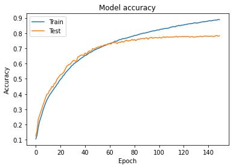

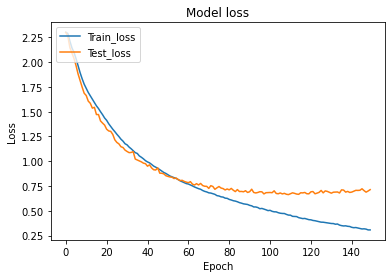

```python
# Resultados
plot_prediction(150, history)
```

```python
pred_y = CNN.predict(x_test_4D)

target_names = ["airplane","automobile","bird",
               "cat","deer","dog","frog","horse","ship","truck"]

cm = pd.DataFrame(
    confusion_matrix(y_test_oh.argmax(axis=1), pred_y.argmax(axis=1)),
    index= target_names,
    columns=target_names
)
cm
```

|  | airplane | automobile | bird | cat | deer | dog | frog | horse | ship | truck |
| --- | --- | --- | --- | --- | --- | --- | --- | --- | --- | --- |
| airplane | 817 | 8 | 43 | 14 | 26 | 5 | 15 | 9 | 43 | 20 |
| automobile | 10 | 885 | 3 | 9 | 10 | 4 | 10 | 3 | 19 | 47 |
| bird | 43 | 0 | 668 | 40 | 127 | 47 | 43 | 21 | 6 | 5 |
| cat | 21 | 7 | 67 | 555 | 93 | 140 | 56 | 38 | 11 | 12 |
| deer | 8 | 1 | 53 | 27 | 807 | 25 | 30 | 44 | 5 | 0 |
| dog | 10 | 2 | 42 | 138 | 60 | 682 | 19 | 40 | 6 | 1 |
| frog | 7 | 2 | 38 | 42 | 33 | 21 | 842 | 3 | 7 | 5 |
| horse | 8 | 1 | 24 | 18 | 44 | 43 | 5 | 851 | 2 | 4 |
| ship | 43 | 15 | 12 | 9 | 10 | 5 | 9 | 2 | 880 | 15 |
| truck | 25 | 54 | 7 | 16 | 9 | 11 | 8 | 13 | 17 | 840 |

```python
accuracy_score(y_test_oh.argmax(axis=1), pred_y.argmax(axis=1))
```

```
0.7827
```

```python
print(classification_report(y_test_oh.argmax(axis=1), pred_y.argmax(axis=1), target_names=target_names))
```

```
              precision    recall  f1-score   support

    airplane       0.82      0.82      0.82      1000
  automobile       0.91      0.89      0.90      1000
        bird       0.70      0.67      0.68      1000
         cat       0.64      0.56      0.59      1000
        deer       0.66      0.81      0.73      1000
         dog       0.69      0.68      0.69      1000
        frog       0.81      0.84      0.83      1000
       horse       0.83      0.85      0.84      1000
        ship       0.88      0.88      0.88      1000
       truck       0.89      0.84      0.86      1000

    accuracy                           0.78     10000
   macro avg       0.78      0.78      0.78     10000
weighted avg       0.78      0.78      0.78     10000
```

La red profunda con imágenes grises tiene una performance mucho mejor que las anteriores con un accuracy alto de 0.78, precisión moderada alta para casi todas la clases exceptuando las imágenes de gatos

### 4.2 CNN con imágenes en color

Finalmente vamos a estudiar la influencia del color de las imágenes en la *performance* de la clasificación.

Para ello utilizaremos una red convolucional con la misma estructura de la red del apartado anterior pero cambiando la capa de entrada para que podamos introducir las imágenes originales en color, arrays de dimensión (32, 32, 3).

**Ejercicio [0,5 pts]:** Volver a realizar el ejercicio anterior pero modificando la capa de entrada para poder utilizar el conjunto de datos original, de tamaño (50000, 32, 32, 3) para el conjunto de train y (10000, 32, 32, 3) para el conjunto de test. ¿Influye el color de las imágenes en el resultado de la clasificación? Comentar el resultado.

**Nota**: Recordar normalizar las imágenes para que sus valores estén entre 0 y 1.

```python
# Normalizar
(X_train, y_train), (X_test, y_test) = cifar10.load_data()

v_min = np.min(X_train)
v_max = np.max(X_train)

X_train_norm = (X_train - v_min) / (v_max - v_min)
X_test_norm = (X_test - v_min) / (v_max - v_min)

y_train_oh = to_categorical(y_train)
y_test_oh = to_categorical(y_test)
```

```python
X_train_norm.shape
```

```
(50000, 32, 32, 3)
```

```python
# Crear la CNN profunda
CNN_color = Sequential()
CNN_color.add(Conv2D(32, kernel_size=(3, 3), activation="relu", padding="same", input_shape=(32,32,3)))
CNN_color.add(Conv2D(32, kernel_size=(3, 3), activation='relu', padding="same"))
CNN_color.add(MaxPooling2D(pool_size=(2, 2)))
CNN_color.add(Dropout(0.20))
CNN_color.add(Conv2D(64, kernel_size=(3, 3), activation="relu", padding="same"))
CNN_color.add(Conv2D(64, kernel_size=(3, 3), activation='relu', padding="same"))
CNN_color.add(MaxPooling2D(pool_size=(2, 2)))
CNN_color.add(Dropout(0.20))
CNN_color.add(Conv2D(128, kernel_size=(3, 3), activation="relu", padding="same"))
CNN_color.add(Conv2D(128, kernel_size=(3, 3), activation='relu', padding="same"))
CNN_color.add(MaxPooling2D(pool_size=(2, 2)))
CNN_color.add(Dropout(0.20))
CNN_color.add(Flatten())
CNN_color.add(Dense(128, activation='relu'))
CNN_color.add(Dropout(0.20))
CNN_color.add(Dense(out_dims,activation='softmax'))

print(CNN_color.summary())
```

```
Model: "sequential_3"
_________________________________________________________________
 Layer (type)                Output Shape              Param #
=================================================================
 conv2d_7 (Conv2D)           (None, 32, 32, 32)        896

 conv2d_8 (Conv2D)           (None, 32, 32, 32)        9248

 max_pooling2d_3 (MaxPooling  (None, 16, 16, 32)       0
 2D)

 dropout_7 (Dropout)         (None, 16, 16, 32)        0

 conv2d_9 (Conv2D)           (None, 16, 16, 64)        18496

 conv2d_10 (Conv2D)          (None, 16, 16, 64)        36928

 max_pooling2d_4 (MaxPooling  (None, 8, 8, 64)         0
 2D)

 dropout_8 (Dropout)         (None, 8, 8, 64)          0

 conv2d_11 (Conv2D)          (None, 8, 8, 128)         73856

 conv2d_12 (Conv2D)          (None, 8, 8, 128)         147584

 max_pooling2d_5 (MaxPooling  (None, 4, 4, 128)        0
 2D)

 dropout_9 (Dropout)         (None, 4, 4, 128)         0

 flatten_2 (Flatten)         (None, 2048)              0

 dense_10 (Dense)            (None, 128)               262272

 dropout_10 (Dropout)        (None, 128)               0

 dense_11 (Dense)            (None, 10)                1290

=================================================================
Total params: 550,570
Trainable params: 550,570
Non-trainable params: 0
_________________________________________________________________
None
```

```python
# Compile
CNN_color.compile(loss='categorical_crossentropy', optimizer=SGD(learning_rate=0.001, momentum=0.9), metrics=['accuracy'])
```

```python
# Entrenamiento del modelo
start_time = time.time()

history_color = CNN_color.fit(X_train_norm, y_train_oh,
                       validation_data=(X_test_norm, y_test_oh),
                       epochs=150,
                       batch_size=128,
                       verbose=0
                       )

end_time = time.time() - start_time
print(end_time)
```

```
770.5949463844299
```

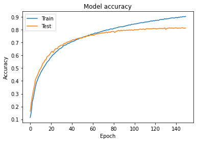

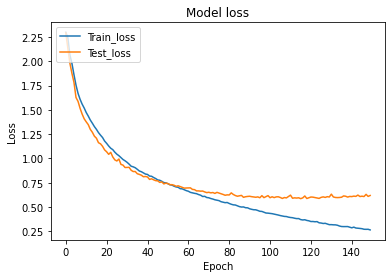

```python
# Resultados
plot_prediction(150, history_color)
```

```python
pred_y = CNN_color.predict(X_test_norm)

target_names = ["airplane","automobile","bird",
               "cat","deer","dog","frog","horse","ship","truck"]

cm = pd.DataFrame(
    confusion_matrix(y_test_oh.argmax(axis=1), pred_y.argmax(axis=1)),
    index= target_names,
    columns=target_names
)
cm
```

|  | airplane | automobile | bird | cat | deer | dog | frog | horse | ship | truck |
| --- | --- | --- | --- | --- | --- | --- | --- | --- | --- | --- |
| airplane | 854 | 15 | 19 | 9 | 10 | 7 | 5 | 12 | 45 | 24 |
| automobile | 8 | 912 | 2 | 3 | 0 | 3 | 3 | 1 | 21 | 47 |
| bird | 64 | 5 | 695 | 42 | 62 | 55 | 41 | 21 | 7 | 8 |
| cat | 19 | 8 | 48 | 596 | 46 | 188 | 43 | 31 | 12 | 9 |
| deer | 17 | 3 | 47 | 45 | 775 | 27 | 20 | 59 | 6 | 1 |
| dog | 6 | 2 | 19 | 95 | 33 | 793 | 11 | 36 | 2 | 3 |
| frog | 6 | 3 | 30 | 36 | 18 | 23 | 865 | 5 | 10 | 4 |
| horse | 11 | 2 | 8 | 19 | 32 | 51 | 2 | 870 | 1 | 4 |
| ship | 43 | 18 | 5 | 8 | 5 | 4 | 2 | 5 | 895 | 15 |
| truck | 20 | 55 | 3 | 6 | 3 | 7 | 3 | 11 | 12 | 880 |

```python
accuracy_score(y_test_oh.argmax(axis=1), pred_y.argmax(axis=1))
```

```
0.8135
```

```python
print(classification_report(y_test_oh.argmax(axis=1), pred_y.argmax(axis=1), target_names=target_names))
```

```
              precision    recall  f1-score   support

    airplane       0.81      0.85      0.83      1000
  automobile       0.89      0.91      0.90      1000
        bird       0.79      0.69      0.74      1000
         cat       0.69      0.60      0.64      1000
        deer       0.79      0.78      0.78      1000
         dog       0.68      0.79      0.73      1000
        frog       0.87      0.86      0.87      1000
       horse       0.83      0.87      0.85      1000
        ship       0.89      0.90      0.89      1000
       truck       0.88      0.88      0.88      1000

    accuracy                           0.81     10000
   macro avg       0.81      0.81      0.81     10000
weighted avg       0.81      0.81      0.81     10000
```

## 5. Comparativa de los modelos implementados y predicción [1,5 puntos]

En este último apartado compararemos los modelos implementados y realizaremos la clasificación de algunas imágenes con el modelo que ha dado los mejores resultados.

### 5.1 Comparativa de los modelos implementados

**Ejercicio [0,5 pts.]:** Realizar una comparativa de los modelos implementados comentando: * La precisión obtenida * La pérdida * El tiempo de entrenamiento * El número de parámetros a entrenar Comentar los resultados obtenidos. En base a los resultados obtenidos ¿Qué modelo seleccionaríais como el mejor?

**Solución:**

Conclusión, te toma como mejor modelo el que implica imágenes de color, porque tiene un accuracy ligeramente mayor y una precisión en general similar con mejoras significativas en algunas clases, además el tiempo de entrenamiento es el mismo

```python
import pandas as pd
```

```python
resultados = {"ANN": {"time":142.75, "Accuracy":0.42},
"CNN_Mono con GPU": {"time":82.51, "Accuracy":0.43},
"CNN_Mono con CPU": {"time":583.20, "Accuracy":0.25},
"CNN_Deep_Gris": {"time":770.45, "Accuracy":0.78},
"CNN_Deep_Color": {"time":770.59, "Accuracy":0.81}}
```

```python
pd.DataFrame.from_dict(resultados).T
```

|  | time | Accuracy |
| --- | --- | --- |
| ANN | 142.75 | 0.42 |
| CNN_Mono con GPU | 82.51 | 0.43 |
| CNN_Mono con CPU | 583.20 | 0.25 |
| CNN_Deep_Gris | 770.45 | 0.78 |
| CNN_Deep_Color | 770.59 | 0.81 |

### 5.2 Análisis de la mejor solución

**Ejercicio [0,5 pts.]:** Realizar un análisis de las medidas estadísticas más relevantes del modelo seleccionado en el apartado anterior y representar su matriz de confusión.

¿Qué clase es la que mejor se predice? ¿Y la que peor resultados obtiene?

Comentar los resultados

Reporte de clasificación del modelo de Red Convolucional con imágenes a color

```python
# Informe
print(classification_report(y_test_oh.argmax(axis=1), pred_y.argmax(axis=1), target_names=target_names))
```

```
              precision    recall  f1-score   support

    airplane       0.81      0.85      0.83      1000
  automobile       0.89      0.91      0.90      1000
        bird       0.79      0.69      0.74      1000
         cat       0.69      0.60      0.64      1000
        deer       0.79      0.78      0.78      1000
         dog       0.68      0.79      0.73      1000
        frog       0.87      0.86      0.87      1000
       horse       0.83      0.87      0.85      1000
        ship       0.89      0.90      0.89      1000
       truck       0.88      0.88      0.88      1000

    accuracy                           0.81     10000
   macro avg       0.81      0.81      0.81     10000
weighted avg       0.81      0.81      0.81     10000
```

- El modelo coches y barcos (89%); por otra parte la clase con peores resultados los obtienen la clase perro (68%) y gato; sin embargo la performance para la mayoría de las clases es alta en cuanto a la precisión.
- Los f1-score, como métrica de evaluación general son altos, exceptuando la clase gato que es moderado alto.
- El accuracy del modelo es alto.
- Con respecto al recall, la clase que fue clasificada de forma correcta en mayor medida son los coches (91%) y la peor los gatos. El recall general también es 0.81, lo cual es alto y signifca que el modelo a clasificado de forma correcta el 81% de las veces o 8 de cada 10 imágenes son reconocidas por la red

```python
# Matriz de confusión
cm
```

|  | airplane | automobile | bird | cat | deer | dog | frog | horse | ship | truck |
| --- | --- | --- | --- | --- | --- | --- | --- | --- | --- | --- |
| airplane | 854 | 15 | 19 | 9 | 10 | 7 | 5 | 12 | 45 | 24 |
| automobile | 8 | 912 | 2 | 3 | 0 | 3 | 3 | 1 | 21 | 47 |
| bird | 64 | 5 | 695 | 42 | 62 | 55 | 41 | 21 | 7 | 8 |
| cat | 19 | 8 | 48 | 596 | 46 | 188 | 43 | 31 | 12 | 9 |
| deer | 17 | 3 | 47 | 45 | 775 | 27 | 20 | 59 | 6 | 1 |
| dog | 6 | 2 | 19 | 95 | 33 | 793 | 11 | 36 | 2 | 3 |
| frog | 6 | 3 | 30 | 36 | 18 | 23 | 865 | 5 | 10 | 4 |
| horse | 11 | 2 | 8 | 19 | 32 | 51 | 2 | 870 | 1 | 4 |
| ship | 43 | 18 | 5 | 8 | 5 | 4 | 2 | 5 | 895 | 15 |
| truck | 20 | 55 | 3 | 6 | 3 | 7 | 3 | 11 | 12 | 880 |

### 5.3 Predicción de algunas imágenes del conjunto de test

**Ejercicio [0,5 pts.]:** Visualizar diez imágenes al azar del conjunto de test. Mostrar la etiqueta real y la predicción.

```python
# Visualización
y_tesPred = pd.DataFrame(zip(y_test, pred_y.argmax(axis=1)), columns=["Y_test", "Y_pred"])
```

Tomamos la muestra aleatoria de 10

```python
sample = y_tesPred.sample(10)
```

```python
sample
```

|  | Y_test | Y_pred |
| --- | --- | --- |
| 8121 | [0] | 0 |
| 957 | [3] | 3 |
| 8016 | [4] | 5 |
| 404 | [8] | 8 |
| 6379 | [8] | 8 |
| 5795 | [7] | 7 |
| 6255 | [6] | 6 |
| 430 | [2] | 2 |
| 6803 | [6] | 6 |
| 6832 | [1] | 1 |

```python
sample.index.to_list()
```

```
[8121, 957, 8016, 404, 6379, 5795, 6255, 430, 6803, 6832]
```

```python
def showImgPred(i):
  plt.figure(dpi = 100)
  img = X_test[i]
  labelNumber = int(y_test[i])
  labelPred = pred_y.argmax(axis=1)[i]
  plt.title("Img: {}, pred: {}".format(labels[labelNumber], labels[labelPred]))
  plt.imshow(img)
  plt.show()
```

[figure not shown]

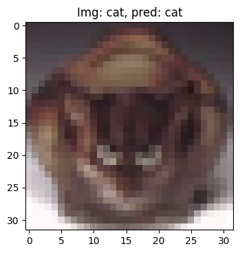

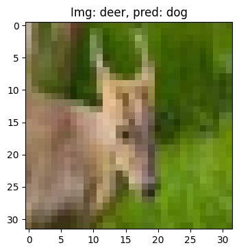

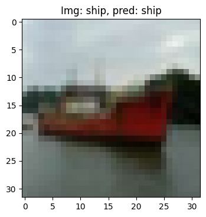

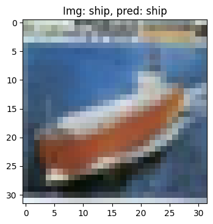

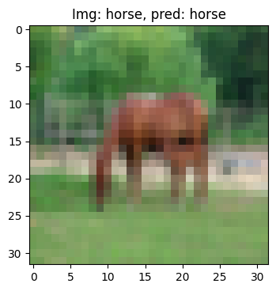

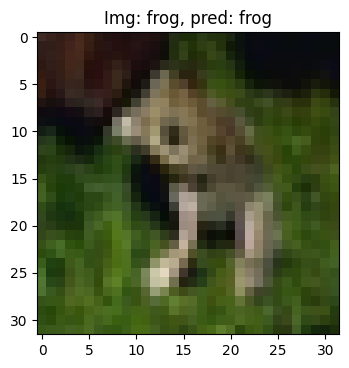

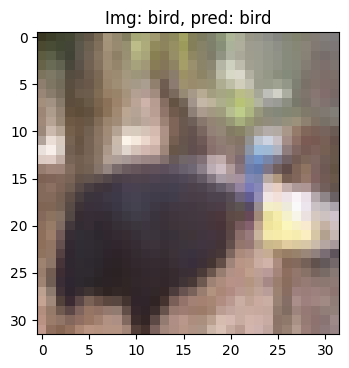

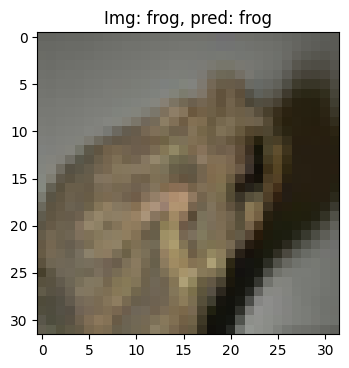

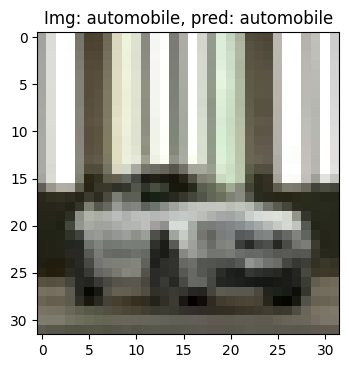

```python
for i in sample.index.to_list():
    showImgPred(i)
```